# `SteppedPower`, an `R`-package

Philipp Mildenberger

4 December 2018

## What?

- `SteppedPower` calculates power for longitudinal intervention studies
- offers tools for visualization of cluster influences
- applicable to various designs:
  - stepped wedge
  - parallel
  - parallel with baseline
  - t.b.c.

## Why?

Software for power calculation of SWD already exists (in R: `swCRTdesign`, `SWSamp`; in Stata: `steppedwedge`). So why yet another power package?

- `SteppedPower` can handle unequal cluster sizes
- constructs exact covariance matrix for non-normal responses
- convenient option to compare power of a SWD to other designs
- focuses on choice of appropriate design

## How?

Calculate power of a z-test

$$\text{power} = \Phi\left(\frac{\theta_A-\theta_0}{\sqrt{\text{Var}(\hat \theta)}}- Z_{1-\frac{\alpha}{2}}\right)$$

where $\text{Var}(\hat \theta)$ depends on the **design matrix** and the **covariance matrix**.

## Design Matrix

- one row per observation
- one column per variable

```r
SteppedPower::construct_DesMat(Cl=c(1,1), design="SWD")
```

```
##      trtvec
## [1,]      0 1 0 0
## [2,]      1 1 1 0
## [3,]      1 1 0 1
## [4,]      0 1 0 0
## [5,]      0 1 1 0
## [6,]      1 1 0 1
```

```r
SteppedPower::construct_DesMat(Cl=c(1,1), design="parallel", timepoints=3)
```

```
##      trtvec
## [1,]      0 1 0 0
## [2,]      0 1 1 0
## [3,]      0 1 0 1
## [4,]      1 1 0 0
## [5,]      1 1 1 0
## [6,]      1 1 0 1
```

## Covariance Matrix

- one block of dim timepoints$^2$ per cluster

```r
SteppedPower::construct_CovBlk(timepoints=3, sigma=0.5, tau=0.1)
```

```
##      [,1] [,2] [,3]
## [1,] 0.26 0.01 0.01
## [2,] 0.01 0.26 0.01
## [3,] 0.01 0.01 0.26
```

```r
SteppedPower:::construct_CovMat(SumCl=2, timepoints=3, sigma=c(0.5,1), tau=0.1)
```

```
## 6 x 6 sparse Matrix of class "dgCMatrix"
##
## [1,] 0.26 0.01 0.01 .    .    .
## [2,] 0.01 0.26 0.01 .    .    .
## [3,] 0.01 0.01 0.26 .    .    .
## [4,] .    .    .    1.01 0.01 0.01
## [5,] .    .    .    0.01 1.01 0.01
## [6,] .    .    .    0.01 0.01 1.01
```

## Main function

call the function `wlsMixedPower`

```r
library(SteppedPower)
wlsMixed_swd <- wlsMixedPower(EffSize=2, sigma=1, tau=0.1,
                              N=c(4,1), Cl=c(1,1), design="SWD")
wlsMixed_swd$Power
```

```
## [1] 0.4267799
```

- N denotes the sizes of the two clusters, sigma is adjusted for:

```r
wlsMixed_swd$CovarianceMatrix
```

```
## 6 x 6 sparse Matrix of class "dgCMatrix"
##
## [1,] 0.26 0.01 0.01 .    .    .
## [2,] 0.01 0.26 0.01 .    .    .
## [3,] 0.01 0.01 0.26 .    .    .
## [4,] .    .    .    1.01 0.01 0.01
## [5,] .    .    .    0.01 1.01 0.01
## [6,] .    .    .    0.01 0.01 1.01
```

```r
wlsMixed_swd$DesignMatrix
```

```
##      trtvec
## [1,]      0 1 0 0
## [2,]      1 1 1 0
## [3,]      1 1 0 1
## [4,]      0 1 0 0
## [5,]      0 1 1 0
## [6,]      1 1 0 1
```

## Visualization - Weight Matrix

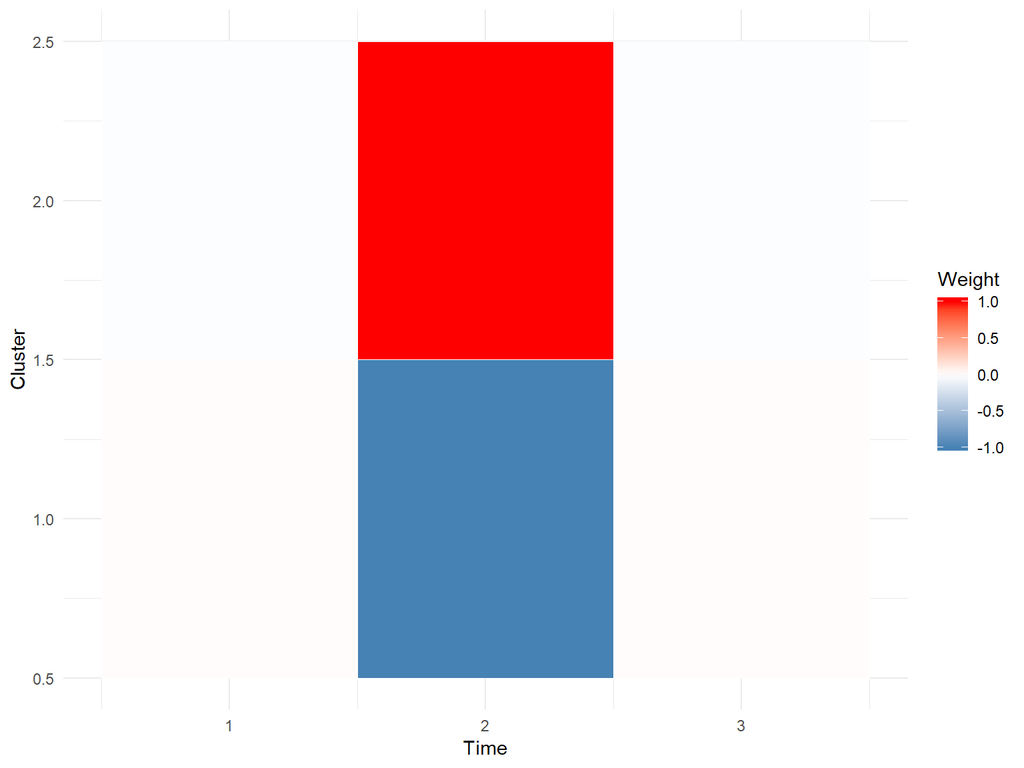

```r
plot_swd <- plot_wlsPower(wlsMixed_swd)
plot_swd[[1]]
```

- first and third period have (almost) no effect on trt estimate (!)
- power quite low

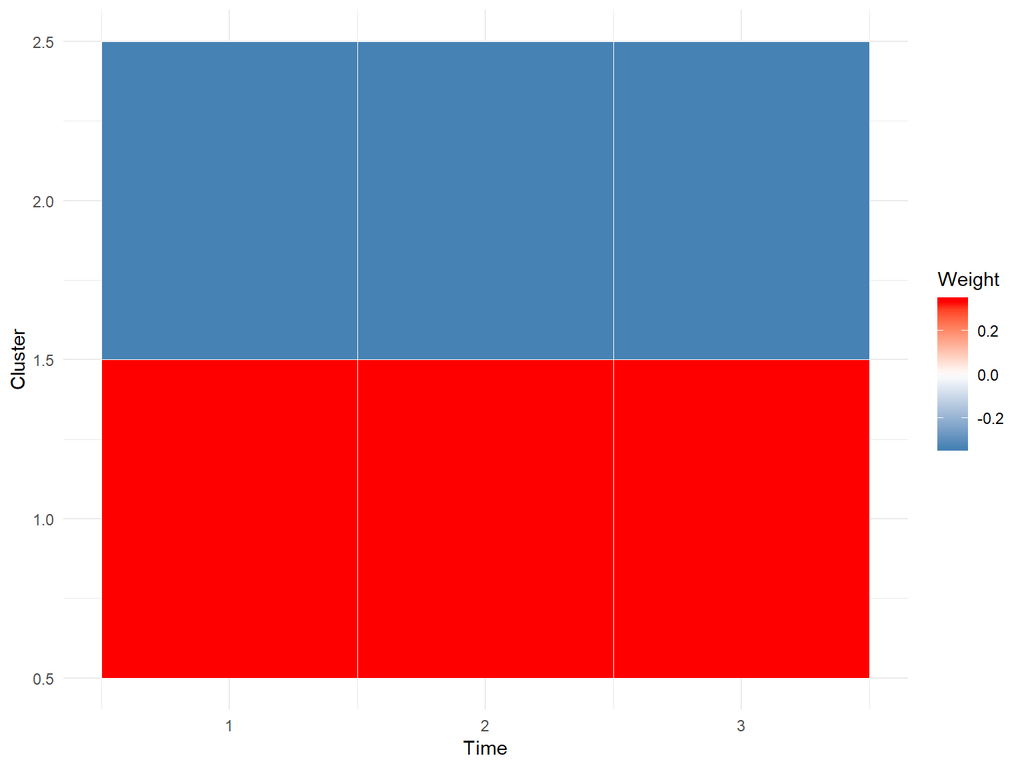

```r
wlsMixed_parll <- wlsMixedPower(EffSize=2, sigma=1, tau=0.1,
                                N=c(4,1), Cl=c(1,1), design="parallel",timepoints=3)
plot_wlsPower(wlsMixed_parll)[[1]]
```

```r
wlsMixed_parll$Power
```

```
## [1] 0.8569321
```

## Weight Matrix - high cluster correlation

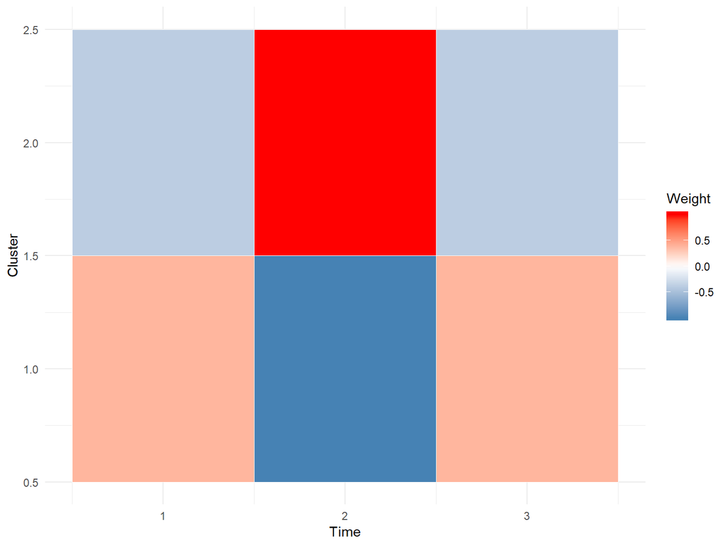

```r
wlsMixed_swd2 <- wlsMixedPower(EffSize=2, sigma=1, tau=1,
                                N=c(4,1), Cl=c(1,1), design="SWD")
plot_wlsPower(wlsMixed_swd2)[[1]]
```

```r
wlsMixed_swd2$Power
```

```
## [1] 0.331045
```

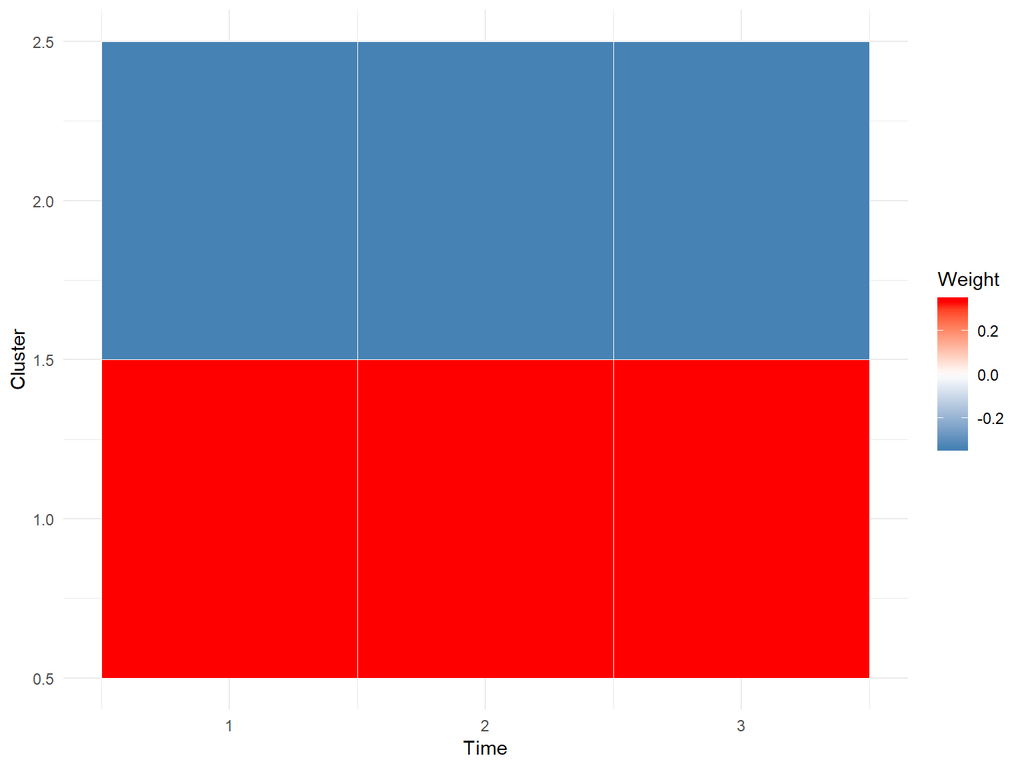

```r
wlsMixed_parll2 <- wlsMixedPower(EffSize=2, sigma=1, tau=1,
                                N=c(4,1), Cl=c(1,1), design="parallel",timepoints=3)
plot_wlsPower(wlsMixed_parll2)[[1]]
```

```r
wlsMixed_parll2$Power
```

```
## [1] 0.2509214
```

## 4 Clusters

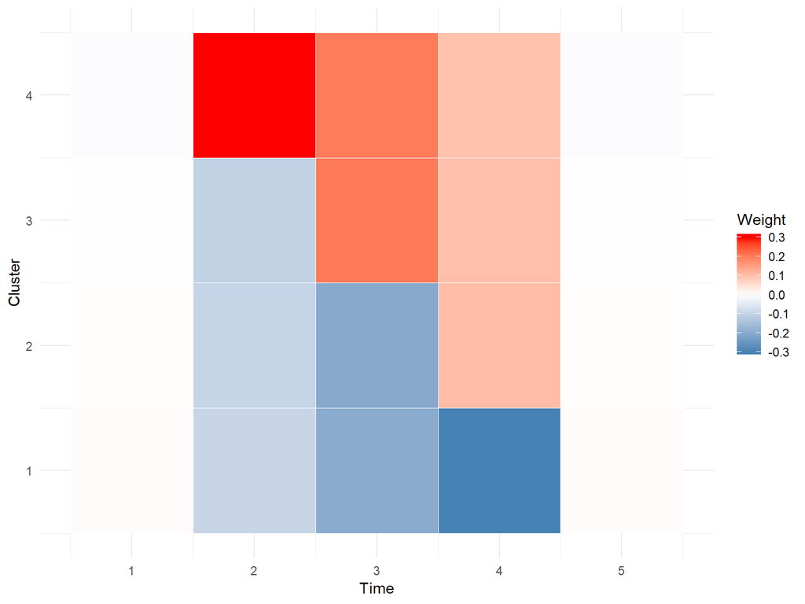

```r
wlsMixed_4swd <- wlsMixedPower(EffSize=1.5, sigma=1, tau=0.1,
                                N=1, Cl=c(1,1,1,1), design="SWD")
plot_wlsPower(wlsMixed_4swd)[[1]]
```

```r
wlsMixed_4swd$Power
```

```
## [1] 0.6513879
```

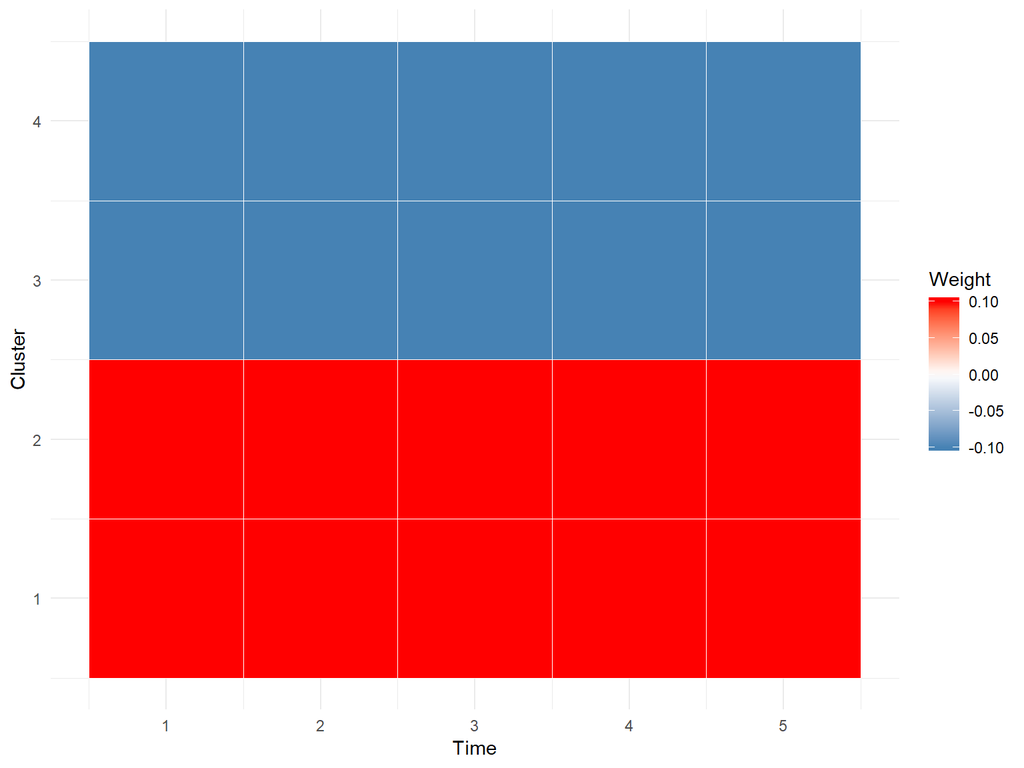

```r
wlsMixed_4parll <- wlsMixedPower(EffSize=1.5, sigma=1, tau=0.1,
                                N=1, Cl=c(2,2), design="parallel",timepoints=5)
plot_wlsPower(wlsMixed_4parll)[[1]]
```

```r
wlsMixed_4parll$Power
```

```
## [1] 0.9054599
```

## compairing designs

function `compare_designs` returns power for three settings with different designs, but the same number of clusters and observation periods

```r
compare_designs(EffSize=1.5, sigma=1 ,tau=.1, Cl=c(1,1,1,1))
```

```
##       Stepped.Wedge  parallel parallel.with.baseline
## Power     0.6513879 0.9054599              0.8370339
```

```r
compare_designs(EffSize=1.5, sigma=1 ,tau= 1, Cl=c(1,1,1,1))
```

```
##       Stepped.Wedge  parallel parallel.with.baseline
## Power     0.4906856 0.2778103              0.4099681
```

## Cluster Weigths ( Setting with 100 Clusters)

```r
swd100 <- wlsMixedPower(EffSize=0.1,sigma=1,tau=.15,Cl=rep(2,50))
```

### Plot of

- weight matrix,
- absolute cluster weights,
- ablolute period weights

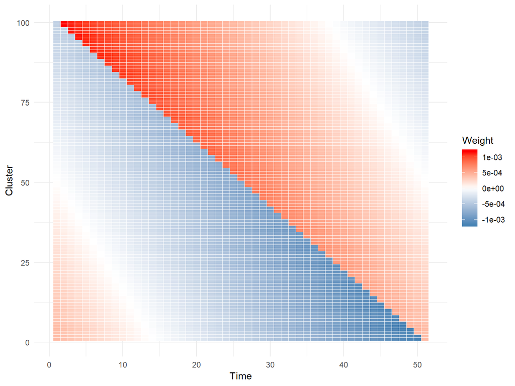

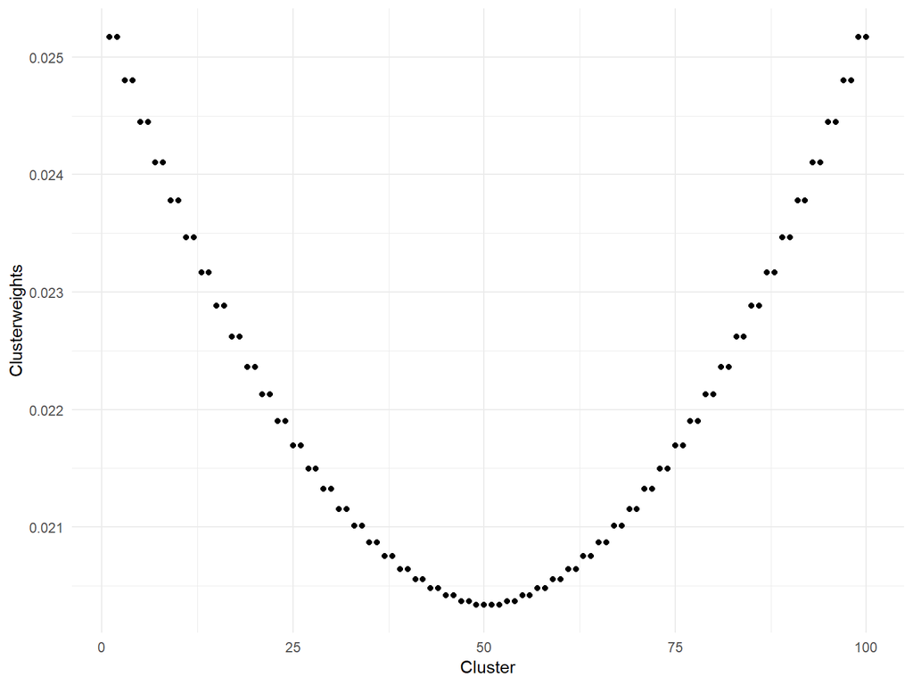

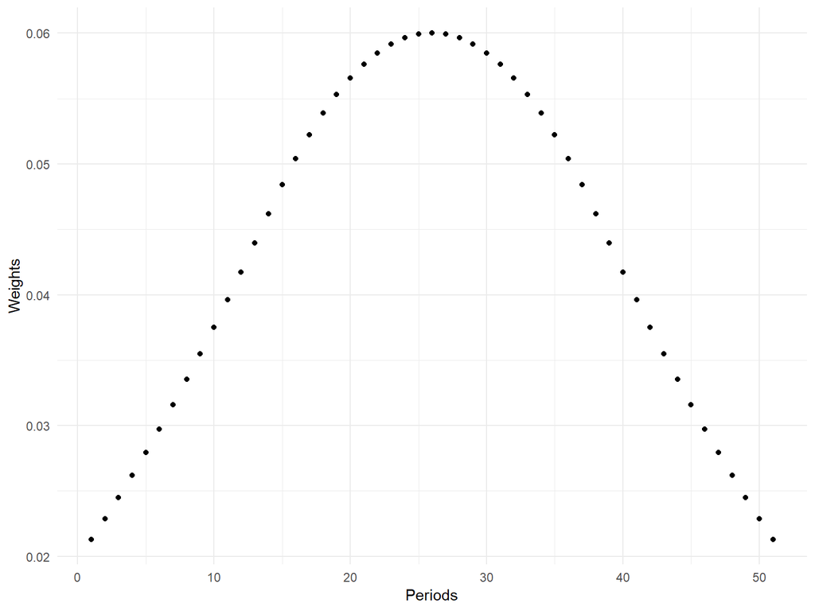

### Power comparison

```r
compare_designs(EffSize=0.1,sigma=1,tau=.15,Cl=rep(2,50))
```

```
##       Stepped.Wedge  parallel parallel.with.baseline
## Power     0.6983238 0.6832034              0.6842652
```

## Prospects

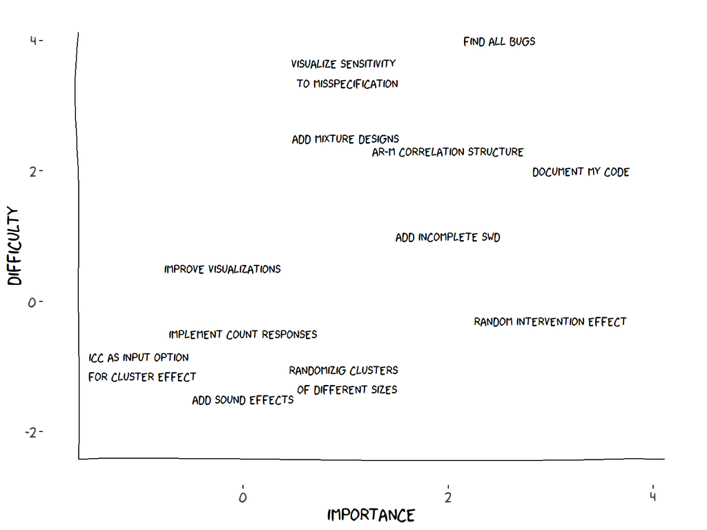

current state of the package `devtools::install.github("PMildenb/SteppedPower")`